# iRPCA of e12 coronary progenitors

# Load data

Log-transformed counts per million .Rdata object for the e12 fetal coronary progenitor dataset should be downloaded from Figshare via the following link: https://ndownloader.figshare.com/files/11086496 MD5: a6a4606279435b694e70e8d6e9997a7c

Save the file in the data/ folder

# all r1

PC13 separates a small number of contaminating Hbb-b1+ cells. Remove these cells from further analysis.

`r`r cordir=‘all_r1/’ system(paste0(‘mkdir’,cordir)); system(paste0(‘mkdir’,file.path(cordir,‘biplots’)));

dt.pca = copy(dt.fv1_NS.good) setkey(dt.pca)

n.pcs = 15 if(recalculate.pca){ pca.d1 <- dimplots.pca.lowMem(dt.pca,cell.info,cordir,suffix=‘’,max.genes = 30,ncp=n.pcs, min.cells.detect=1,n.cores = 8) plot.ggpairs.wExptCols(cell.info,dir=cordir,suffix=’‘,num.pcs = n.pcs,height=25,width=25,sigType = ’Sig’,annot.expt = F) }

# remove some hemoglobin-high RBC precursors

pc.scores = fread(paste0(cordir, ‘PC_allscores.csv’)) dt.pca.2 = merge(dt.pca[gene %in% c(‘Hbb-b1’,‘Pecam1’)], pc.scores, by=‘cell.name’)

cutoff.point <- 0.3 if(with(dt.pca.2[gene==‘Hbb-b1’], cor(log10.cpm, PC13.score)) < 0) cutoff.point <- -cutoff.point

ggplot(dt.pca.2, aes(PC13.pos, PC13.neg, color = log10.cpm)) + geom_point() + geom_abline(intercept = -cutoff.point) + scale_color_gradientn(colours=brewer.pal(9,‘YlOrBr’)[3:9]) + facet_wrap(~gene)+ coord_fixed() ggsave(‘all_r1/all_r1_hbbHi_separation.pdf’,height = 3, width = 4)

if(cutoff.point > 0){ cells.hbb.hi = pc.scores[ PC13.score > cutoff.point, cell.name] } else{ cells.hbb.hi = pc.scores[ PC13.score < cutoff.point, cell.name] }

save(cells.hbb.hi, file = ‘all_r1/cells_hbb_hi.RData’) write.table(cells.hbb.hi, file = ‘all_r1/cells_hbb_hi.txt’)

with(pc.scores, plot(PC13.pos, PC13.neg, pch = 20)) with(pc.scores[cell.name %in% cells.hbb.hi],points(PC13.pos, PC13.neg, col = ‘green’, pch = 20 ))

# all r2 (endocardial vs Aplnr)

2. rPCA, 15 PCs, all genes minus cell cycle (noCC). (endocard_refine_r1)

`r`r rm(list=ls()[ls() %like% ’cells.*’]) cordir=‘all_r2/’ system(paste0(‘mkdir’,cordir)); system(paste0(‘mkdir’,file.path(cordir,‘biplots’)));

load(‘all_r1/cells_hbb_hi.RData’)

dt.pca = dt.fv1_NS.good[!cell.name %in% cells.hbb.hi][!gene %in% genes.cc] setkey(dt.pca)

n.pcs = 15 if(recalculate.pca){

pca.d1 <- dimplots.pca.lowMem(dt.pca,cell.info,cordir,suffix=‘’,max.genes = 30,ncp=n.pcs, min.cells.detect=1,n.cores = 8) plot.ggpairs.wExptCols(cell.info,dir=cordir,suffix=’‘,num.pcs = n.pcs,height=25,width=25,sigType = ’Sig’,annot.expt = F)

make.facet.biplots(dt.pca,c(paste0(‘PC’,1),paste0(‘PC’,15)),cordir,size=1.5, plot.pdf = T, custom.genes = c(‘Aplnr’,‘Smoc1’,‘Pdgfra’,‘A2m’,‘Fbln2’,‘Fbln5’,‘Sfrp2’,‘Kcne3’,‘Gja4’, ‘Cxcr7’,‘Gja5’),height = 6, width = 9) } # # remove coronary cells pc.scores = fread(paste0(cordir, ‘PC_allscores.csv’)) dt.pca.2 = merge(dt.pca[gene %in% c(‘Kcne3’,‘Aplnr’,‘Smoc1’,‘Gpr126’)], pc.scores, by=‘cell.name’)

cutoff.point <- 0.18 if(with(dt.pca.2[gene==‘Kcne3’], cor(log10.cpm, PC1.score)) < 0) cutoff.point <- -cutoff.point

ggplot(dt.pca.2, aes(PC1.score, PC15.score, color = log10.cpm)) + geom_point(size=.7) + geom_vline(xintercept = cutoff.point) + scale_color_gradientn(colours=brewer.pal(9,‘YlOrBr’)[3:9]) + coord_fixed() + facet_wrap(~gene)

ggsave(‘all_r2/cells_kcne3_all_r2_separation.pdf’,height = 3, width = 4)

if(cutoff.point > 0){ cells.kcne3.all_r2 = pc.scores[ PC1.score > cutoff.point, cell.name] } else{ cells.kcne3.all_r2 = pc.scores[ PC1.score < cutoff.point, cell.name] }

save(cells.kcne3.all_r2, file = ‘all_r2/cells_kcne3_all_r2.RData’) write.table(cells.kcne3.all_r2, file = ‘all_r2/cells_kcne3_all_r2.txt’)

with(pc.scores, plot(PC1.score, PC15.score, pch = 20)) + with(pc.scores[!cell.name %in% cells.kcne3.all_r2],points(PC1.score, PC15.score, col = ‘green’, pch = 20 ))

# endocard refine 1

3. rPCA, 15 PCs, noCC.

1. ```
   PC2 and PC5 separate the Gpr126+ population from the Cldn11+ population.
   ```

2. ```
   Gpr126+ population appears continuous with the Apln-, PC5-high part of the Cldn11+ population.
   ```

`r`r cordir=‘endocard_refine_r1/’ system(paste0(‘mkdir’,cordir)); system(paste0(‘mkdir’,file.path(cordir,‘biplots’)));

load(‘all_r1/cells_hbb_hi.RData’) load(‘all_r2/cells_kcne3_all_r2.RData’)

dt.pca = dt.fv1_NS.good[!cell.name %in% c(cells.hbb.hi, cells.kcne3.all_r2)] dt.pca = dt.pca[!gene %in% genes.cc] setkey(dt.pca)

n.pcs = 15 if(recalculate.pca){ pca.d1 <- dimplots.pca.lowMem(dt.pca,cell.info,cordir,suffix=‘’,max.genes = 30,ncp=n.pcs, min.cells.detect=1,n.cores = 8) plot.ggpairs.wExptCols(cell.info,dir=cordir,suffix=’‘,num.pcs = n.pcs,height=25,width=25,sigType = ’Sig’,annot.expt = F)

make.facet.biplots(dt.pca,c(paste0(‘PC’,2),paste0(‘PC’,15)),cordir,size=1.5, plot.pdf = T,num.genes = 10) } # Further refinement of endocardial population pc.scores = fread(paste0(cordir, ‘PC_allscores.csv’)) dt.pca.2 = merge(dt.pca[gene %in% c(‘Pdgfra’,‘Fbln2’,‘Itih3’,‘Kcne3’)], pc.scores, by=‘cell.name’)

cutoff.point <- 0.2 if(with(dt.pca.2[gene==‘Kcne3’], cor(log10.cpm, PC2.score)) < 0) cutoff.point <- -cutoff.point

ggplot(dt.pca.2, aes(PC2.score, PC15.score, color = log10.cpm)) + geom_point(size = .7) + scale_color_gradientn(colours=brewer.pal(9,‘YlOrBr’)[3:9]) + facet_wrap(~gene) + geom_vline(xintercept = cutoff.point) + coord_fixed() ggsave(‘endocard_refine_r1/endocard_refine_r1_separation.pdf’,height = 6, width = 9)

if(cutoff.point > 0){ cells.endocardRefine.r1.v2 = pc.scores[ PC2.score < cutoff.point, cell.name] } else{ cells.endocardRefine.r1.v2 = pc.scores[ PC2.score > cutoff.point, cell.name] } cells.endocardRefine.r1.v2 = pc.scores[ PC2.score < cutoff.point, cell.name]

save(cells.endocardRefine.r1.v2, file = ‘endocard_refine_r1/cells_endocard_refine_r1.RData’) write.table(cells.endocardRefine.r1.v2, file = ‘endocard_refine_r1/cells_endocard_refine_r1.txt’)

with(pc.scores, plot(PC2.score, PC15.score, pch = 20)) + with(pc.scores[cell.name %in% cells.endocardRefine.r1.v2],points(PC2.score, PC15.score, col = ‘green’, pch = 20 ))

# endocard refine 2 (remove Aplnr+ population)

There is possibly a continuum between the endocardial (Gpr126) population and the rest of the cells. Remove the Aplnr+ population using PC2 and PC5, because it is not directly continuous with the endocardial population, to continue analyzing the transition between endocardial and other cell types.

`r`r cordir=‘endocard_refine_r2/’ system(paste0(‘mkdir’,cordir)); system(paste0(‘mkdir’,file.path(cordir,‘biplots’)));

load(‘endocard_refine_r1/cells_endocard_refine_r1.RData’)

dt.pca = dt.fv1_NS.good[cell.name %in% c(cells.endocardRefine.r1.v2)] dt.pca = dt.pca[!gene %in% genes.cc] setkey(dt.pca)

n.pcs = 15 if(recalculate.pca){

pca.d1 <- dimplots.pca.lowMem(dt.pca,cell.info,cordir,suffix=‘’,max.genes = 30,ncp=n.pcs, min.cells.detect=1,n.cores = 8) plot.ggpairs.wExptCols(cell.info,dir=cordir,suffix=’‘,num.pcs = n.pcs, height=25,width=25,sigType = ’Sig’,annot.expt = F, plot.read.depth = F) plot.ggpairs.wExptCols(cell.info,dir=cordir,suffix=‘’,num.pcs = n.pcs, height=25,width=25,sigType = ’PC’,annot.expt = F, plot.read.depth = F)

make.facet.biplots(dt.pca,c(paste0(‘PC’,2),paste0(‘PC’,5)),cordir,size=2, plot.pdf = T, num.genes = 10)

make.facet.biplots(dt.pca,c(paste0(‘PC’,2),paste0(‘PC’,4)),cordir,size=1.5, plot.pdf = T, custom.genes = c(‘Gpr126’,‘Fbln2’,‘Pdgfra’,‘Aplnr’,‘A2m’,‘Nr2f2’), height = 6, width = 9) }

# Further refinement of endocardial population

rm(pc.scores, dt.pca.2) pc.scores = fread(paste0(cordir, ‘PC_allscores.csv’)) dt.pca.2 = merge(dt.pca[gene %in% c(‘Pdgfra’,‘Gpr126’,‘Limch1’,‘Aplnr’)], pc.scores,by=‘cell.name’)

cutoff.1 <- -.1 if(with(dt.pca.2[gene==‘Aplnr’], cor(log10.cpm, PC2.score)) < 0) cutoff.1 <- -cutoff.1 cutoff.2 <- -.1 if(with(dt.pca.2[gene==‘Pdgfra’], cor(log10.cpm, PC5.score)) < 0) cutoff.2 <- -cutoff.2

ggplot(dt.pca.2, aes(PC2.score, PC5.score, color = log10.cpm)) + geom_point() + geom_hline(yintercept = cutoff.2) + geom_vline(xintercept = cutoff.1) + scale_color_gradientn(colours=brewer.pal(9,‘YlOrBr’)[3:9]) + facet_wrap(~gene) + coord_fixed() ggsave(‘endocard_refine_r2/endocard_refine_r2_separation.pdf’,height = 9, width = 11)

if(cutoff.1 > 0){ cells.aplnr.hi <- pc.scores[PC2.score > cutoff.1, cell.name] } else{ cells.aplnr.hi <- pc.scores[PC2.score < cutoff.1, cell.name] }

if(cutoff.2 > 0){ cells.pdgfra.hi <- pc.scores[PC5.score < cutoff.2, cell.name] } else{ cells.pdgfra.hi <- pc.scores[PC5.score > cutoff.2, cell.name] }

cells.endocardRefine.r2.v2 = union(cells.pdgfra.hi, cells.aplnr.hi)

save(cells.endocardRefine.r2.v2, file = ‘endocard_refine_r2/cells_endocard_refine_r2.RData’) write.table(cells.endocardRefine.r2.v2, file = ‘endocard_refine_r2/cells_endocard_refine_r2.txt’)

plt=with(pc.scores, plot(PC2.score, PC5.score, pch = 20)) + with(pc.scores[cell.name %in% cells.endocardRefine.r2.v2],points(PC2.score, PC5.score, col = ‘green’, pch = 20 )) plt pdf(‘endocard_refine_r2/endocard_refine_r2_separation_verification.pdf’, height = 4, width = 4) plt dev.off()

# endocard refine 3 (define small Fbln5+ population)

PC8 separates a small subpopulation of Fbln5+ cells; these may be an interesting progenitor population. However, there are too few Fbln5+ cells to study.

`r`r cordir=‘endocard_refine_r3/’ system(paste0(‘mkdir’,cordir)); system(paste0(‘mkdir’,file.path(cordir,‘biplots’)));

load(‘endocard_refine_r2/cells_endocard_refine_r2.RData’)

dt.pca = dt.fv1_NS.good[cell.name %in% c(cells.endocardRefine.r2.v2)] dt.pca = dt.pca[!gene %in% genes.cc] dt.pca = dt.pca[!gene %in% c(‘Rn45s’,‘Lars2’,‘Malat1’)] setkey(dt.pca)

n.pcs = 10 if(recalculate.pca){

pca.d1 <- dimplots.pca.lowMem(dt.pca,cell.info,cordir,suffix=‘’,max.genes = 30,ncp=n.pcs, min.cells.detect=1,n.cores = 8) plot.ggpairs.wExptCols(cell.info,dir=cordir,suffix=’‘,num.pcs = n.pcs,height=25,width=25,sigType = ’Sig’,annot.expt = F)

make.facet.biplots(dt.pca,c(paste0(‘PC’,2),paste0(‘PC’,8)),cordir,size=2, plot.pdf = T) }

# Further refinement of endocardial population

pc.scores = fread(paste0(cordir, ‘PC_allscores.csv’)) dt.pca.2 = merge(dt.pca[gene %in% c(‘Fbln2’,‘Fbln5’,‘Smoc1’,‘Limch1’)], pc.scores, by=‘cell.name’)

cutoff.1 <- .18 if(with(dt.pca.2[gene==‘Fbln5’], cor(log10.cpm, PC8.score)) < 0) cutoff.1 <- -cutoff.1

ggplot(dt.pca.2, aes(PC2.score, PC8.score, color = log10.cpm)) + geom_point() + scale_color_gradientn(colours=brewer.pal(9,‘YlOrBr’)[3:9]) + facet_wrap(~gene) + coord_fixed() + theme(legend.position = ‘none’)+ geom_hline(yintercept = cutoff.1) ggsave(‘endocard_refine_r3/endo_refine_r3_separation.pdf’,height = 9, width = 11)

if(cutoff.1 > 0){ cells.endocardRefine.r3.v2.Fbln5 = pc.scores[PC8.score > cutoff.1, cell.name] cells.endocardRefine.r3.v2.rest = pc.scores[PC8.score <= cutoff.1, cell.name] } else{ cells.endocardRefine.r3.v2.Fbln5 = pc.scores[PC8.score < cutoff.1, cell.name] cells.endocardRefine.r3.v2.rest = pc.scores[PC8.score >= cutoff.1, cell.name] }

plt=with(pc.scores, plot(PC2.score, PC8.score, pch = 20)) + with(pc.scores[cell.name %in% cells.endocardRefine.r3.v2.rest],points(PC2.score, PC8.score, col = ‘green’, pch = 20 )) plt pdf(‘endocard_refine_r3/endocard_refine_r3_separation_verification.pdf’, height = 4, width = 4) plt dev.off()

save(cells.endocardRefine.r3.v2.Fbln5, file = ‘endocard_refine_r3/cells_.endocardRefine.r3.v2.Fbln5.Rdata’) save(cells.endocardRefine.r3.v2.rest, file = ‘endocard_refine_r3/cells.endocardRefine.r3.v2.rest.Rdata’)

# endocard refine 4 (remove small Fbln2 population)

PC4 separates a small population of Fbln2+ cells. These are likely SVv cells.

`r`r rm(list=ls()[ls() %like% ’cells.*’]) cordir=‘endocard_refine_r4/’ system(paste0(‘mkdir’,cordir)); system(paste0(‘mkdir’,file.path(cordir,‘biplots’)));

load(‘endocard_refine_r3/cells.endocardRefine.r3.v2.rest.Rdata’)

dt.pca = dt.fv1_NS.good[cell.name %in% c(cells.endocardRefine.r3.v2.rest)] dt.pca = dt.pca[!gene %in% genes.cc] dt.pca = dt.pca[!gene %in% c(‘Rn45s’,‘Lars2’,‘Malat1’)] setkey(dt.pca)

n.pcs = 10 if(recalculate.pca){

pca.d1 <- dimplots.pca.lowMem(dt.pca,cell.info,cordir,suffix=‘’,max.genes = 30,ncp=n.pcs, min.cells.detect=1,n.cores = 8) plot.ggpairs.wExptCols(cell.info,dir=cordir,suffix=’‘,num.pcs = n.pcs,height=25,width=25,sigType = ’Sig’,annot.expt = F)

make.facet.biplots(dt.pca,c(paste0(‘PC’,2),paste0(‘PC’,4)),cordir,size=2, plot.pdf = T) }

pc.scores = fread(paste0(cordir, ‘PC_allscores.csv’)) dt.pca.2 = merge(dt.pca[gene %in% c(‘Fbln2’,‘Pdgfra’,‘Gpr126’,‘Limch1’)], pc.scores, by=‘cell.name’)

cutoff.1 <- .25 if(with(dt.pca.2[gene==‘Fbln2’], cor(log10.cpm, PC4.score)) < 0) cutoff.1 <- -cutoff.1

ggplot(dt.pca.2, aes(PC2.score, PC4.score, color = log10.cpm)) + geom_point() + scale_color_gradientn(colours=brewer.pal(9,‘YlOrBr’)[3:9]) + facet_wrap(~gene) + coord_fixed() + theme(legend.position = ‘none’)+ geom_hline(yintercept = cutoff.1) + coord_fixed() ggsave(‘endocard_refine_r4/endo_refine_r4_separation.pdf’,height = 9, width = 11)

if(cutoff.1 > 0){ cells.endocardRefine.r4.v2.Fbln2 = pc.scores[PC4.score > cutoff.1, cell.name] cells.endocardRefine.r4.v2.rest = pc.scores[PC4.score <= cutoff.1, cell.name] } else{ cells.endocardRefine.r4.v2.Fbln2 = pc.scores[PC4.score < cutoff.1, cell.name] cells.endocardRefine.r4.v2.rest = pc.scores[PC4.score >= cutoff.1, cell.name]

}

plt=with(pc.scores, plot(PC2.score, PC4.score, pch = 20, asp=1)) + with(pc.scores[cell.name %in% cells.endocardRefine.r4.v2.rest],points(PC2.score, PC4.score, col = ‘green’, pch = 20 ))

pdf(‘endocard_refine_r4/endocard_refine_r4_separation_verification.pdf’, height = 4, width = 4) plt dev.off()

save(cells.endocardRefine.r4.v2.Fbln2, file = ‘endocard_refine_r4/cells_.endocardRefine.r4.v2.Fbln5.Rdata’) save(cells.endocardRefine.r4.v2.rest, file = ‘endocard_refine_r4/cells.endocardRefine.r4.v2.rest.Rdata’)

# endocard refine 5 (define endocardial population)

PC1 is cell cycle Endocardial population appears to be continuous with primarily the Pdgfra mesenchymal population. Use PC2.score to define endocardial cells (Gpr126-hi). Use PC3.score to define the Pdgfra mesenchymal population (for now).

`r`r rm(list=ls()[ls() %like% ’cells.*’]) cordir=‘endocard_refine_r5/’ system(paste0(‘mkdir’,cordir));

```
mkdir: endocard_refine_r5/: File exists
```

`r`r system(paste0(‘mkdir’,file.path(cordir,‘biplots’)));

```
mkdir: endocard_refine_r5//biplots: File exists
```

`r`r load(‘endocard_refine_r4/cells.endocardRefine.r4.v2.rest.Rdata’) dt.pca = dt.fv1_NS.good[cell.name %in% c(cells.endocardRefine.r4.v2.rest)] dt.pca = dt.pca[!gene %in% genes.cc] dt.pca = dt.pca[!gene %in% c(‘Rn45s’,‘Lars2’,‘Malat1’)] setkey(dt.pca) n.pcs = 10 if(recalculate.pca){ pca.d1 <- dimplots.pca.lowMem(dt.pca,cell.info,cordir,suffix=‘’,max.genes = 30,ncp=n.pcs, min.cells.detect=1,n.cores = 8, min.numgenes = 3500) plot.ggpairs.wExptCols(cell.info,dir=cordir,suffix=’‘,num.pcs = n.pcs,height=25,width=25,sigType = ’Sig’,annot.expt = F) make.facet.biplots(dt.pca,c(paste0(‘PC’,2),paste0(‘PC’,10)),cordir,size=2, plot.pdf = T) make.facet.biplots(dt.pca,c(paste0(‘PC’,2),paste0(‘PC’,3)),cordir,size=2, plot.pdf = T) } # Define the endocardial population based on PC2 (corresponds to Nrk+/Pdgfra- transition). pc.scores = fread(paste0(cordir, ‘PC_allscores.csv’)) dt.pca.2 = merge(dt.pca[gene %in% c(‘Nrk’,‘Pdgfra’,‘Gpr126’,‘Cldn11’)], pc.scores, by=‘cell.name’) cutoff.1 <- .2 # Endocardial separation if(with(dt.pca.2[gene==‘Gpr126’], cor(log10.cpm, PC2.score)) < 0) cutoff.1 <- -cutoff.1 cutoff.2 <- .1 # Pdgfra separation (not defining Pdgfra cells here since there is a lot of other heterogeneity) if(with(dt.pca.2[gene==‘Pdgfra’], cor(log10.cpm, PC3.score)) < 0) cutoff.2 <- -cutoff.2 ggplot(dt.pca.2, aes(PC2.score, PC3.score, color = log10.cpm)) + geom_point() + scale_color_gradientn(colours=brewer.pal(9,‘YlOrBr’)[3:9]) + facet_wrap(~gene) + coord_fixed() + theme(legend.position = ‘none’)+ geom_vline(xintercept = cutoff.1) + geom_hline(yintercept = cutoff.2) ggsave(‘endocard_refine_r5/endo_refine_r5_separation.pdf’,height = 9, width = 11)

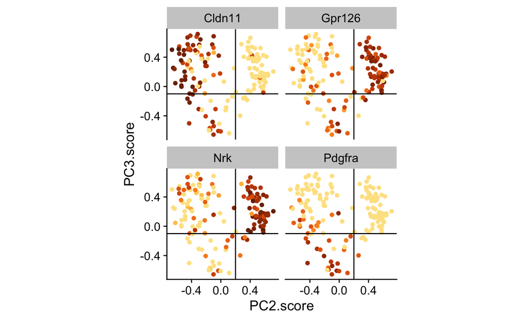

`r`r # Use PC2 to separate if(cutoff.1 < 0){ cells.endocardRefine.r5.v2.endocard = pc.scores[PC2.score < cutoff.1, cell.name] } else{ cells.endocardRefine.r5.v2.endocard = pc.scores[PC2.score > cutoff.1, cell.name] } if(cutoff.2 > 0){ cells.endocardRefine.r5.v2.pdgfra = pc.scores[(!cell.name %in% cells.endocardRefine.r5.v2.endocard) & PC3.score > cutoff.2, cell.name] } else{ cells.endocardRefine.r5.v2.pdgfra = pc.scores[(!cell.name %in% cells.endocardRefine.r5.v2.endocard) & PC3.score < cutoff.2, cell.name] } # verify endocardial definition. with(pc.scores, plot(PC2.score, PC3.score, pch = 20))+ with(pc.scores[cell.name %in% cells.endocardRefine.r5.v2.endocard],points(PC2.score, PC3.score, col = ‘green’, pch = 20 ))+ with(pc.scores[cell.name %in% cells.endocardRefine.r5.v2.pdgfra],points(PC2.score, PC3.score, col = ‘red’, pch = 20 ))

```
integer(0)
```

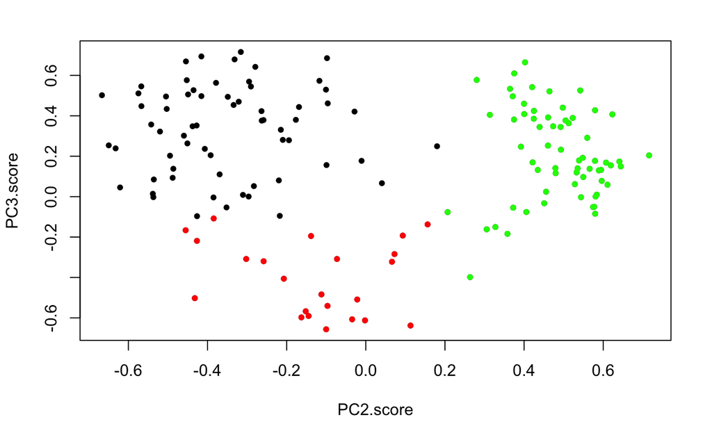

`r`r save(cells.endocardRefine.r5.v2.endocard, file = ‘endocard_refine_r5/cells_endocardRefine.r5.v2.endocard.Rdata’) write.table(cells.endocardRefine.r5.v2.endocard, file = ‘endocard_refine_r5/cells_endocardRefine.r5.v2.endocard.txt’) save(cells.endocardRefine.r5.v2.pdgfra, file = ‘endocard_refine_r5/cells_endocardRefine.r5.v2.pdgfra.Rdata’)

# all_r3: (no endocard; remove valve)

No subtypes with small number of genes were detected; instead, cells with low number of genes just look like low-quality cells. Remove cells with < 3500 genes detected to improve clustering.

PC2 and PC3 scores show a continuum from valve-like (Corin+) to CV Plexus (Apln+)-like, connected by at least 2 distinct intermediate populations (Fbln2+, A2m+); however, there are too many intermediate populations for PCA to clearly separate them all.

Use PC2.score and PC3.score to remove the Corin+/Fbln2- valve population and run rPCA on the rest of the cells so that heterogeneity in the rest of the continuum can be better revealed.

```r
rm(list=ls()[ls() %like% 'cells.*'])
cordir='all_r3/'
system(paste0('mkdir ',cordir));
system(paste0('mkdir ',file.path(cordir,'biplots')));

load('all_r1/cells_hbb_hi.RData')
load('endocard_refine_r5/cells_endocardRefine.r5.v2.endocard.Rdata')
load('endocard_refine_r5/cells_endocardRefine.r5.v2.pdgfra.Rdata')
load('endocard_refine_r4/cells_.endocardRefine.r4.v2.Fbln5.Rdata')

dt.pca = dt.fv1_NS.good[!cell.name %in% c(cells.hbb.hi,
                                          cells.endocardRefine.r5.v2.endocard,
                                          cells.endocardRefine.r5.v2.pdgfra,
                                          cells.endocardRefine.r4.v2.Fbln2)][!gene %in% genes.cc]
setkey(dt.pca)
#
n.pcs = 15
if(recalculate.pca){

pca.d1 <- dimplots.pca.lowMem(dt.pca,cell.info,cordir,suffix='',max.genes = 30,ncp=n.pcs,
                              min.cells.detect=1,n.cores = 8, min.numgenes=3500)
plot.ggpairs.wExptCols(cell.info,dir=cordir,suffix='',num.pcs = n.pcs,height=25,width=25,sigType = 'Sig',annot.expt = F)

make.facet.biplots(dt.pca,c(paste0('PC',2),paste0('PC',3)),cordir,size=1.5, plot.pdf = T)
}

rm(pc.scores, dt.pca.2)
pc.scores = fread(paste0(cordir, 'PC_allscores.csv'))
nrow(pc.scores)
dt.pca.2 = merge(dt.pca[gene %in% c('Aplnr','Fst','Corin','Fbln2')],
                 pc.scores[,c('cell.name',colnames(pc.scores)[colnames(pc.scores) %like% "PC[0-9]"]), with = F],
                 by = 'cell.name')

intercept=-.5
plt=ggplot(dt.pca.2, aes(PC2.score, PC3.score, color = log10.cpm)) + geom_point() +
  scale_color_gradientn(colours=brewer.pal(9,'YlOrBr')[3:9]) +
  facet_wrap(~gene) + coord_fixed() +
  geom_abline(intercept = intercept)
plt
save_plot('all_r3/all_r3_valve_separation.pdf',plt,ncol=2, nrow=2, base_height = 3.5)

cells.allr3.valve = pc.scores[PC3.score < PC2.score + intercept, cell.name]
cells.allr3.rest = pc.scores[!cell.name %in% cells.allr3.valve, cell.name]

# Verify separation of valve-like population
with(pc.scores, plot(PC2.score, PC3.score, pch = 20)) +
  with(pc.scores[cell.name %in% cells.allr3.rest],points(PC2.score, PC3.score, col = 'green', pch = 20 ))


save(cells.allr3.valve, file = 'all_r3/all_r3_valve.RData')
write.table(cells.allr3.valve, file = 'all_r3/all_r3_valve.txt')
save(cells.allr3.rest, file = 'all_r3/all_r3_rest.RData')
```

# all_r4 (remove 3 immune cells)

PC15 separates 3 contaminating immune cells - remove them (too few cells to study)

```r
rm(list=ls()[ls() %like% 'cells.*'])
cordir='all_r4/'
system(paste0('mkdir ',cordir));
system(paste0('mkdir ',file.path(cordir,'biplots')));

load('all_r3/all_r3_rest.RData')

dt.pca = dt.fv1_NS.good[cell.name %in% cells.allr3.rest][!gene %in% genes.cc]
setkey(dt.pca)

n.pcs = 15
if(recalculate.pca){

pca.d1 <- dimplots.pca.lowMem(dt.pca,cell.info,cordir,suffix='',max.genes = 30,ncp=n.pcs,
                              min.cells.detect=1,n.cores = 8)
plot.ggpairs.wExptCols(cell.info,dir=cordir,suffix='',num.pcs = n.pcs,height=25,width=25,sigType = 'Sig',annot.expt = F)

make.facet.biplots(dt.pca,c(paste0('PC',15),paste0('PC',15)), cordir,size=1.5, plot.pdf = T, ax.suf =c('.pos','.neg'), num.genes = 15)
}


# remove 3 immune cells
pc.scores = fread(paste0(cordir, 'PC_allscores.csv'))
dt.pca.2 = merge(dt.pca[gene %in% c('Pecam1','C1qb','Esam')],
                 pc.scores[,c('cell.name',colnames(pc.scores)[colnames(pc.scores) %like% "PC[0-9]"]), with = F],
                 by = 'cell.name')

cutoff <- -.3
plt=ggplot(dt.pca.2, aes(PC15.pos, PC15.neg, color = log10.cpm)) + geom_point() +
  scale_color_gradientn(colours=brewer.pal(9,'YlOrBr')[3:9]) +
  facet_wrap(~gene) + coord_fixed() +
  geom_abline(intercept = -cutoff)
plt
save_plot('all_r4/all_r4_separation.pdf',plt,ncol=3, nrow=1, base_height = 2.5)

# define the immune cells
cells.allr4.immune = pc.scores[PC15.score < cutoff, cell.name]
cells.allr4.rest = pc.scores[PC15.score >= cutoff, cell.name]


with(pc.scores, plot(PC15.pos, PC15.neg, pch = 20))
with(pc.scores[cell.name %in% cells.allr4.immune],points(PC15.pos, PC15.neg, col = 'green', pch = 20 ))

save(cells.allr4.immune, file = 'all_r4/all_r4_immune.RData')
write.table(cells.allr4.immune, file = 'all_r4/all_r4_immune.txt')
save(cells.allr4.rest, file = 'all_r4/all_r4_rest.RData')
write.table(cells.allr4.rest, file = 'all_r4/all_r4_rest.txt')
```

# all_r5 (remove SVv)

PC2 and PC7 separates the Fbln2+ SVv population, which is strongly continous with the A2m+ SVc population. There are also a few cells that appear continuous with the Apln+ CV Plexus population. The SVc and CV Plexus populations also appear strongly continuous with one another.

Separate and remove the SVv population using PC2 and PC7 to better reveal heterogeneity in the SVc-CV Plexus continuum.

```r
rm(list=ls()[ls() %like% 'cells.*'])
cordir='all_r5/'
system(paste0('mkdir ',cordir));
system(paste0('mkdir ',file.path(cordir,'biplots')));

load('all_r4/all_r4_rest.RData')

dt.pca = dt.fv1_NS.good[cell.name %in% c(cells.allr4.rest)][!gene %in% genes.cc]
setkey(dt.pca)
cell.info = copy(fv1_NS.cell.info)
cell.info[, experiment := sort.plate]
cell.info[, experiment_color := sort.plate_color]
#
n.pcs = 15
if(recalculate.pca){

pca.d1 <- dimplots.pca.lowMem(dt.pca,cell.info,cordir,suffix='',max.genes = 30,ncp=n.pcs,
                              min.cells.detect=1,n.cores = 8)
plot.ggpairs.wExptCols(cell.info,dir=cordir,suffix='',num.pcs = n.pcs,height=25,width=25,sigType = 'Sig',annot.expt = F)
plot.ggpairs.wExptCols(cell.info,dir=cordir,suffix='',num.pcs = n.pcs,height=25,width=25,sigType = 'PC',annot.expt = F)

# make.facet.biplots(dt.pca,c(paste0('PC',2),paste0('PC',8)), cordir,size=1.5, plot.pdf = T, num.genes = 15)
make.facet.biplots(dt.pca,c(paste0('PC',2),paste0('PC',7)), cordir,size=1.5, plot.pdf = T, num.genes = 15)
}

# Plot genes on PC pos/neg biplots
# registerDoMC(8)
# foreach(i=1:n.pcs) %dopar% {
#   make.facet.biplots(dt.pca,c(paste0('PC',i),paste0('PC',i)),cordir,ax.suf = c('.pos','.neg'),size=1.5,
#                      height = 18,width = 22,num.genes = 30, plot.pdf = T)
# }


pc.scores = fread(paste0(cordir, 'PC_allscores.csv'))
dt.pca.2 = merge(dt.pca[gene %in% c('Vwf','A2m','Apln','Fbln2')],
                 pc.scores[,c('cell.name',colnames(pc.scores)[colnames(pc.scores) %like% "PC[0-9]"]), with = F],
                 by = 'cell.name')


cutoff.pc7 <- -.1
cutoff.pc2 <- -.1

plt=ggplot(dt.pca.2, aes(PC2.score, PC7.score, color = log10.cpm)) + geom_point(size=.8) +
  scale_color_gradientn(colours=brewer.pal(9,'YlOrBr')[3:9]) +
  facet_wrap(~gene) + coord_fixed() +
  geom_hline(yintercept = cutoff.pc7) +
  geom_vline(xintercept = cutoff.pc2)
plt
save_plot('all_r5/all_r5_separation.pdf',plt,ncol=2, nrow=2, base_height = 3)

cells.allr5.SVv = pc.scores[(PC2.score < cutoff.pc2) & (PC7.score < cutoff.pc7), cell.name]
cells.allr5.rest = pc.scores[!cell.name %in% cells.allr5.SVv, cell.name]

save(cells.allr5.SVv, file = 'all_r5/all_r5_SVv.RData')
write.table(cells.allr5.SVv, file = 'all_r5/all_r5_SVv.txt')
save(cells.allr5.rest, file = 'all_r5/all_r5_rest.RData')
write.table(cells.allr5.rest, file = 'all_r5/all_r5_rest.txt')


with(pc.scores, plot(PC2.score, PC7.score, pch = 20))
with(pc.scores[cell.name %in% cells.allr5.rest],points(PC2.score, PC7.score, col = 'green', pch = 20 ))
```

# all_r6 (remove SVc)

PC2 and PC3 reveal a continuum from SVc to CV Plexus and from CV Plexus to a pre-artery (Gja4+/Nr2f2-) population.

Separate the SVc population by PC2.score to analyze better the CV Plexus-Arterial transition. Define a boundary based on the transition from Mrc1+ (SVc) to Apln+ (CV Plexus)

```r
rm(list = ls()[ls() %like% "cells.*"])
cordir = "all_r6/"
system(paste0("mkdir ", cordir))
system(paste0("mkdir ", file.path(cordir, "biplots")))

load("all_r5/all_r5_rest.RData")

dt.pca = dt.fv1_NS.good[cell.name %in% cells.allr5.rest][!gene %in% genes.cc]
setkey(dt.pca)

n.pcs = 10
if (recalculate.pca) {

    pca.d1 <- dimplots.pca.lowMem(dt.pca, cell.info, cordir, suffix = "", max.genes = 30,
        ncp = n.pcs, min.cells.detect = 1, n.cores = 8, min.numgenes = 3500)
    plot.ggpairs.wExptCols(cell.info, dir = cordir, suffix = "", num.pcs = n.pcs,
        height = 25, width = 25, sigType = "Sig", annot.expt = F)

    # registerDoMC(8) foreach(i=1:n.pcs) %dopar% {
    # make.facet.biplots(dt.pca,c(paste0('PC',i),paste0('PC',i)),cordir,ax.suf =
    # c('.pos','.neg'),size=1.5, height = 18,width = 22,num.genes = 30, plot.pdf
    # = T) }
    make.facet.biplots(dt.pca, c(paste0("PC", 2), paste0("PC", 3)), cordir,
        size = 1.5, plot.pdf = T)

}


pc.scores = fread(paste0(cordir, "PC_allscores.csv"))
print(nrow(pc.scores))
dt.pca.2 = merge(dt.pca[gene %in% c("Mrc1", "Gja4", "Nr2f2", "Apln")], pc.scores,
    by = "cell.name")

# Cutoff to define SVc-CV Plexus boundary
cutoff = 0.15

plt = ggplot(dt.pca.2, aes(PC2.score, PC3.score, color = log10.cpm)) + geom_point(size = 0.8) +
    scale_color_gradientn(colours = brewer.pal(9, "YlOrBr")[3:9]) + facet_wrap(~gene) +
    coord_fixed() + geom_vline(xintercept = cutoff)
plt
save_plot("all_r6/all_r6_separation.pdf", plt, ncol = 2, nrow = 2, base_height = 2.5)

# Define the cutoff to remove SVc cells and explore CV Plexus-arterial
# heterogeneity better
cells.allr6.SVc = pc.scores[PC2.score > cutoff, cell.name]
cells.allr6.rest = pc.scores[!cell.name %in% cells.allr6.SVc, cell.name]

save(cells.allr6.SVc, file = "all_r6/all_r6_SVc.RData")
write.table(cells.allr6.SVc, file = "all_r6/all_r6_SVc.txt")
save(cells.allr6.rest, file = "all_r6/all_r6_rest.RData")
write.table(cells.allr6.rest, file = "all_r6/all_r6_rest.txt")

with(pc.scores, plot(PC2.score, PC3.score, pch = 20))
with(pc.scores[cell.name %in% cells.allr6.rest], points(PC2.score, PC3.score,
    col = "green", pch = 20))
```

# all_r7 (Define Arterial cells)

PC3 separates pre-artery cells from CV plexus cells. Define the pre-artery population here based on PC3 and the transition from Nr2f2+ (CV Plexus) to Gja4+ (pre-artery).

```r
rm(list=ls()[ls() %like% 'cells.*'])
cordir='all_r7/'
system(paste0('mkdir ',cordir));
system(paste0('mkdir ',file.path(cordir,'biplots')));

load('all_r6/all_r6_rest.RData')

dt.pca = dt.fv1_NS.good[cell.name %in% cells.allr6.rest][!gene %in% genes.cc]
setkey(dt.pca)
cell.info = copy(fv1_NS.cell.info)
cell.info[, experiment := sort.plate]
cell.info[, experiment_color := sort.plate_color]
cell.info[, sum.counts := num.mouse.reads]

n.pcs = 10
if(recalculate.pca){

pca.d1 <- dimplots.pca.lowMem(dt.pca,cell.info,cordir,suffix='',max.genes = 30,ncp=n.pcs,
                              min.cells.detect=1,n.cores = 8, min.numgenes = 3500)
plot.ggpairs.wExptCols(cell.info,dir=cordir,suffix='',num.pcs = n.pcs,height=25,width=25,sigType = 'Sig',annot.expt = F)

# make.facet.biplots(dt.pca,c(paste0('PC',1),paste0('PC',3)),cordir,size=1.5, plot.pdf = T)
# make.facet.biplots(dt.pca,c(paste0('PC',1),paste0('PC',7)),cordir,size=1.5, plot.pdf = T)
# make.facet.biplots(dt.pca,c(paste0('PC',3),paste0('PC',7)),cordir,size=1.5, plot.pdf = T)

# make.facet.biplots(dt.pca,c(paste0('PC',3),paste0('PC',10)),cordir,size=1.5, plot.pdf = T)
# make.facet.biplots(dt.pca,c(paste0('PC',3),paste0('PC',9)),cordir,size=1.5, plot.pdf = T)
#
# registerDoMC(detectCores())
# foreach(i=1:n.pcs) %dopar% {
#   make.facet.biplots(dt.pca,c(paste0('PC',i),paste0('PC',i)),cordir,ax.suf = c('.pos','.neg'),size=1.5,
#                      height = 12,width = 15,num.genes = 15, plot.pdf = T, suffix = '')
# }

}


# Define arterial cells
pc.scores = fread(paste0(cordir, 'PC_allscores.csv'))
dt.pca.2 = merge(dt.pca[gene %in% c('Cxcr4','Nr2f2','Gja4','Gja5')],
                 pc.scores[,c('cell.name',colnames(pc.scores)[colnames(pc.scores) %like% "PC[0-9]"]), with = F],
                 by = 'cell.name')

cutoff <- .4
plt=ggplot(dt.pca.2, aes(PC1.score, PC3.score, color = log10.cpm)) + geom_point(size=1) +
  scale_color_gradientn(colours=brewer.pal(9,'YlOrBr')[3:9]) +
  facet_wrap(~gene) + coord_fixed() +
  geom_hline(yintercept = cutoff)
plt
save_plot('all_r7/all_r7_separation.pdf',plt,ncol=2, nrow=2, base_height = 2.5)


if(cutoff > 0){
  cells.allr7.artl = pc.scores[(PC3.score > cutoff), cell.name]
}else{
  cells.allr7.artl = pc.scores[(PC3.score < cutoff), cell.name]
}
cells.allr7.rest = pc.scores[!cell.name %in% cells.allr7.artl, cell.name]

save(cells.allr7.artl, file = 'all_r7/all_r7_artl.Rdata')
write.table(cells.allr7.artl, file = 'all_r7/all_r7_artl.txt')
save(cells.allr7.rest, file = 'all_r7/all_r7_rest.RData')
write.table(cells.allr7.rest, file = 'all_r7/all_r7_rest.txt')

with(pc.scores, plot(PC1.score, PC3.score, pch = 20))
with(pc.scores[cell.name %in% cells.allr7.artl],points(PC1.score, PC3.score, col = 'green', pch = 20 ))
```

# all_r8 (define Tbx1+ population)

PC10 separates a small population of Tbx1+ cells.

```r
rm(list=ls()[ls() %like% 'cells.*'])
cordir='all_r8/'
system(paste0('mkdir ',cordir));
system(paste0('mkdir ',file.path(cordir,'biplots')));

load('all_r7/all_r7_rest.RData')

dt.pca = dt.fv1_NS.good[cell.name %in% cells.allr7.rest][!gene %in% genes.cc]
setkey(dt.pca)
cell.info = copy(fv1_NS.cell.info)
cell.info[, experiment := sort.plate]
cell.info[, experiment_color := sort.plate_color]
cell.info[, sum.counts := num.mouse.reads]
#
n.pcs = 10
if(recalculate.pca){

pca.d1 <- dimplots.pca.lowMem(dt.pca,cell.info,cordir,suffix='',max.genes = 30,ncp=n.pcs,
                              min.cells.detect=1,n.cores = 8, min.numgenes = 3500)
plot.ggpairs.wExptCols(cell.info,dir=cordir,suffix='',num.pcs = n.pcs,height=25,width=25,sigType = 'Sig',annot.expt = F)
# plot.ggpairs.wExptCols(cell.info,dir=cordir,suffix='',num.pcs = n.pcs,height=25,width=25,sigType = 'PC',annot.expt = F)
#
# make.facet.biplots(dt.pca,c(paste0('PC',1),paste0('PC',2)),cordir,size=1.5, plot.pdf = T)
# make.facet.biplots(dt.pca,c(paste0('PC',2),paste0('PC',4)),cordir,size=1.5, plot.pdf = T)
#
make.facet.biplots(dt.pca,c(paste0('PC',1),paste0('PC',10)),cordir,size=1.5, plot.pdf = T)
# make.facet.biplots(dt.pca,c(paste0('PC',3),paste0('PC',10)),cordir,size=1.5, plot.pdf = T)
# make.facet.biplots(dt.pca,c(paste0('PC',3),paste0('PC',9)),cordir,size=1.5, plot.pdf = T)
#
# registerDoMC(detectCores())
# foreach(i=c(1:2,10)) %dopar% {
#   make.facet.biplots(dt.pca,c(paste0('PC',i),paste0('PC',i)),cordir,ax.suf = c('.pos','.neg'),size=1.5,
#                      height = 12,width = 15,num.genes = 15, plot.pdf = T, suffix = '')
# }
}

pc.scores = fread(paste0(cordir, 'PC_allscores.csv'))
dt.pca.2 = merge(dt.pca[gene %in% c('Tbx1','Fbln5','Cd24a','Mfap2')],
                 pc.scores[,c('cell.name',colnames(pc.scores)[colnames(pc.scores) %like% "PC[0-9]"]), with = F],
                 by = 'cell.name')

cutoff=-.1
plt=ggplot(dt.pca.2, aes(PC10.pos, PC10.neg, color = log10.cpm)) + geom_point(size=1) +
  scale_color_gradientn(colours=brewer.pal(9,'YlOrBr')[3:9]) +
  facet_wrap(~gene) + coord_fixed() +
  geom_abline(intercept = -cutoff)
plt
save_plot('all_r8/all_r8_separation.pdf',plt,ncol=2, nrow=2, base_height = 2.5)

if(cutoff < 0){
  cells.allr8.Tbx1 = pc.scores[PC10.score < cutoff, cell.name]

}else{
  cells.allr8.Tbx1 = pc.scores[PC10.score > cutoff, cell.name]

}
cells.allr8.rest = pc.scores[!cell.name %in% cells.allr8.Tbx1, cell.name]

save(cells.allr8.Tbx1, file = 'all_r8/all_r8_Tbx1.RData')
write.table(cells.allr8.Tbx1, file = 'all_r8/all_r8_Tbx1.txt')
save(cells.allr8.rest, file = 'all_r8/all_r8_rest.RData')
write.table(cells.allr8.rest, file = 'all_r8/all_r8_rest.txt')


with(pc.scores, plot(PC10.pos, PC10.neg, pch = 20))
with(pc.scores[cell.name %in% cells.allr8.Tbx1],points(PC10.pos, PC10.neg, col = 'green', pch = 20 ))
```

# all_r9 (define CV1/CV2)

```r
rm(list=ls()[ls() %like% 'cells.*'])
cordir='all_r9/'
system(paste0('mkdir ',cordir));
system(paste0('mkdir ',file.path(cordir,'biplots')));

load('all_r8/all_r8_rest.RData')

dt.pca = dt.fv1_NS.good[cell.name %in% cells.allr8.rest][!gene %in% genes.cc]
setkey(dt.pca)
cell.info = copy(fv1_NS.cell.info)
cell.info[, experiment := sort.plate]
cell.info[, experiment_color := sort.plate_color]
cell.info[, sum.counts := num.mouse.reads]
# #
n.pcs = 10
if(recalculate.pca){

pca.d1 <- dimplots.pca.lowMem(dt.pca,cell.info,cordir,suffix='',max.genes = 30,ncp=n.pcs,
                              min.cells.detect=1,n.cores = 8, min.numgenes = 3500)
plot.ggpairs.wExptCols(cell.info,dir=cordir,suffix='',num.pcs = n.pcs,height=25,width=25,sigType = 'Sig',annot.expt = F)
# plot.ggpairs.wExptCols(cell.info,dir=cordir,suffix='',num.pcs = n.pcs,height=25,width=25,sigType = 'PC',annot.expt = F)
#
make.facet.biplots(dt.pca,c(paste0('PC',2),paste0('PC',2)),cordir,size=1.5, plot.pdf = T, ax.suf = c('.pos','.neg'))
#
# registerDoMC(detectCores())
# foreach(i=c(1:2,10)) %dopar% {
#   make.facet.biplots(dt.pca,c(paste0('PC',i),paste0('PC',i)),cordir,ax.suf = c('.pos','.neg'),size=1.5,
#                      height = 12,width = 15,num.genes = 15, plot.pdf = T, suffix = '')
# }
}

pc.scores = fread(paste0(cordir, 'PC_allscores.csv'))
dt.pca.2 = merge(dt.pca[gene %in% c('Apln','Adm','Id2','Rgs2')],
                 pc.scores[,c('cell.name',colnames(pc.scores)[colnames(pc.scores) %like% "PC[0-9]"]), with = F],
                 by = 'cell.name')


cutoff=-.1
plt=ggplot(dt.pca.2, aes(PC2.pos, PC2.neg, color = log10.cpm)) + geom_point(size=1) +
  scale_color_gradientn(colours=brewer.pal(9,'YlOrBr')[3:9]) +
  facet_wrap(~gene) + coord_fixed() +
  geom_abline(intercept = -cutoff)
plt
save_plot(paste0(cordir,'all_r9_separation.pdf'),plt,ncol=2, nrow=2, base_height = 2.5)

# define CV1 and CV2. Make sure CV1 is Apln+
cells.allr9.cv2 = pc.scores[PC2.score < cutoff, cell.name]
cells.allr9.cv1 = pc.scores[!cell.name %in% cells.allr9.cv2, cell.name]

save(cells.allr9.cv2, file = paste0(cordir,'all_r9_CV2.RData'))
write.table(cells.allr9.cv2, file = paste0(cordir,'all_r9_CV2.txt'))
save(cells.allr9.cv1, file = paste0(cordir,'all_r9_CV1.RData'))
write.table(cells.allr9.cv1, file = paste0(cordir,'all_r9_CV1.txt'))


with(pc.scores, plot(PC2.pos, PC2.neg, pch = 20))
with(pc.scores[cell.name %in% cells.allr9.cv2],points(PC2.pos, PC2.neg, col = 'green', pch = 20 ))
with(pc.scores[cell.name %in% cells.allr9.cv1],points(PC2.pos, PC2.neg, col = 'red', pch = 20 ))
```

# SVv-SVc (define SVc)

The boundaries between SVc and the two populations it is continuous with have now been defined and thus the population is now defined.

```r
rm(list=ls()[ls() %like% 'cells.*'])
cordir='SVv_SVc/'
system(paste0('mkdir ',cordir));
system(paste0('mkdir ',file.path(cordir,'biplots')));


load('all_r5/all_r5_SVv.RData')
load('all_r6/all_r6_SVc.RData')

dt.pca = dt.fv1_NS.good[cell.name %in% c(cells.allr5.SVv, cells.allr6.SVc)][!gene %in% genes.cc]
setkey(dt.pca)
cell.info = copy(fv1_NS.cell.info)
cell.info[, experiment := sort.plate]
cell.info[, experiment_color := sort.plate_color]
cell.info[, sum.counts := num.mouse.reads]

#
n.pcs = 10
if(recalculate.pca){
pca.d1 <- dimplots.pca.lowMem(dt.pca,cell.info,cordir,suffix='',max.genes = 30,ncp=n.pcs,
                              min.cells.detect=1,n.cores = 8, min.numgenes = 3500)
plot.ggpairs.wExptCols(cell.info,dir=cordir,suffix='',num.pcs = n.pcs,height=25,width=25,sigType = 'Sig',annot.expt = F)
#
# make.facet.biplots(dt.pca,c(paste0('PC',1),paste0('PC',2)),cordir,size=1.5, plot.pdf = T)
# make.facet.biplots(dt.pca,c(paste0('PC',1),paste0('PC',3)),cordir,size=1.5, plot.pdf = T)
# make.facet.biplots(dt.pca,c(paste0('PC',2),paste0('PC',3)),cordir,size=1.5, plot.pdf = T)
# make.facet.biplots(dt.pca,c(paste0('PC',2),paste0('PC',9)),cordir,size=1.5, plot.pdf = T)
#
# registerDoMC(detectCores())
# foreach(i=c(1:2,10)) %dopar% {
#   make.facet.biplots(dt.pca,c(paste0('PC',i),paste0('PC',i)),cordir,ax.suf = c('.pos','.neg'),size=1.5,
#                      height = 12,width = 15,num.genes = 15, plot.pdf = T, suffix = '')
# }
}

pc.scores = fread(paste0(cordir, 'PC_allscores.csv'))
dt.pca.2 = merge(dt.pca[gene %in% c('Fbln2','Cxcr7','Vwf','Mrc1')],
                 pc.scores[,c('cell.name',colnames(pc.scores)[colnames(pc.scores) %like% "PC[0-9]"]), with = F],
                 by = 'cell.name')

cutoff = -.13
plt=ggplot(dt.pca.2, aes(PC2.pos, PC2.neg, color = log10.cpm)) + geom_point(size=1) +
  scale_color_gradientn(colours=brewer.pal(9,'YlOrBr')[3:9]) +
  facet_wrap(~gene) + coord_fixed() +
  geom_abline(intercept = -cutoff)
plt
save_plot(paste0(cordir,'separation.pdf'),plt,ncol=2, nrow=2, base_height = 2.5)


# Define boundary between SVc and SVv. Make sure SVv is Fbln2+ and SVc is Mrc1+!
cells.allSVv_SVc.SVc = pc.scores[PC2.score > cutoff, cell.name]
cells.allSVv_SVc.rest = pc.scores[!cell.name %in% cells.allSVv_SVc.SVc, cell.name]

save(cells.allSVv_SVc.SVc, file = paste0(cordir,'all_SVv_SVc_SVc.RData'))
write.table(cells.allSVv_SVc.SVc, file = paste0(cordir,'all_SVv_SVc_SVc.txt'))
save(cells.allSVv_SVc.rest, file = paste0(cordir,'all_SVv_SVc_rest.RData'))
write.table(cells.allSVv_SVc.rest, file = paste0(cordir,'all_SVv_SVc_rest.txt'))

with(pc.scores, plot(PC2.pos, PC2.neg, pch = 20))
with(pc.scores[cell.name %in% cells.allSVv_SVc.SVc],points(PC2.pos, PC2.neg, col = 'green', pch = 20 ))
```

# All r10 (remove SVv)

PC2: strongest (most correlated) signature: Aplnr-Fst SVv-valve gradient.

PC9: Pdgfra+ cells PC10: cell cycle

```r
cordir='all_r10/'
rm(list=ls()[ls() %like% 'cells.*'])
load('all_r1/cells_hbb_hi.RData')
load("endocard_refine_r5/cells_endocardRefine.r5.v2.endocard.Rdata")
load("all_r8/all_r8_Tbx1.RData")
load("all_r9/all_r9_CV1.RData")
load("all_r9/all_r9_CV2.RData")
load("SVv_SVc/all_SVv_SVc_SVc.RData")
load("all_r7/all_r7_artl.Rdata")
load("all_r4/all_r4_immune.RData")

cells.already.defined = c(cells.allr4.immune, cells.hbb.hi, cells.endocardRefine.r5.v2.endocard, cells.allSVv_SVc.SVc, cells.allr9.cv2, cells.allr9.cv1, cells.allr8.Tbx1, cells.allr7.artl)

dt.pca = dt.fv1_NS.good[!cell.name %in% c(cells.already.defined)][!gene %in% genes.cc]
setkey(dt.pca)

n.pcs = 10
if(recalculate.pca){
pca.d1 <- dimplots.pca.lowMem(dt.pca,cell.info,cordir,suffix='',max.genes = 30,ncp=n.pcs,
                              min.cells.detect=1,n.cores = 8, min.numgenes = 3500)
plot.ggpairs.wExptCols(cell.info,dir=cordir,suffix='',num.pcs = n.pcs,height=25,width=25,sigType = 'Sig',annot.expt = F)
# plot.ggpairs.wExptCols(cell.info,dir=cordir,suffix='',num.pcs = n.pcs,height=25,width=25,sigType = 'PC',annot.expt = F)
#
make.facet.biplots(dt.pca,c(paste0('PC',2),paste0('PC',9)),cordir,size=1.5, plot.pdf = T)
# make.facet.biplots(dt.pca,c(paste0('PC',2),paste0('PC',5)),cordir,size=1.5, plot.pdf = T)
# # make.facet.biplots(dt.pca,c(paste0('PC',2),paste0('PC',3)),cordir,size=1.5, plot.pdf = T)
# # make.facet.biplots(dt.pca,c(paste0('PC',2),paste0('PC',9)),cordir,size=1.5, plot.pdf = T)
#
# registerDoMC(detectCores())
# foreach(i=1:n.pcs) %dopar% {
#   make.facet.biplots(dt.pca,c(paste0('PC',i),paste0('PC',i)),cordir,ax.suf = c('.pos','.neg'),size=1.5,
#                      height = 12,width = 15,num.genes = 15, plot.pdf = T, suffix = '')
# }
#
}
pc.scores = fread(paste0(cordir, 'PC_allscores.csv'))
dt.pca.2 = merge(dt.pca[gene %in% c('Aplnr','Fbln2','Fst','Corin')],
                 pc.scores[,c('cell.name',colnames(pc.scores)[colnames(pc.scores) %like% "PC[0-9]"]), with = F],
                 by = 'cell.name')


cutoff = .2
plt=ggplot(dt.pca.2, aes(PC2.score, PC9.score, color = log10.cpm)) + geom_point(size=1) +
  scale_color_gradientn(colours=brewer.pal(9,'YlOrBr')[3:9]) +
  facet_wrap(~gene) + coord_fixed() +
  geom_vline(xintercept = cutoff)
plt
save_plot(paste0(cordir,'separation.pdf'),plt,ncol=2, nrow=2, base_height = 2.5)


cells.allr10.aplnr = pc.scores[PC2.score > cutoff, cell.name]
cells.allr10.rest = pc.scores[!cell.name %in% cells.allr10.aplnr, cell.name]

save(cells.allr10.aplnr, file = paste0(cordir,'all_r10_SVv.RData'))
write.table(cells.allr10.aplnr, file = paste0(cordir,'all_r10_SVv.txt'))
save(cells.allr10.rest, file = paste0(cordir,'all_r10_rest.RData'))
write.table(cells.allr10.rest, file = paste0(cordir,'all_r10_rest.txt'))

with(pc.scores, plot(PC2.score, PC9.score, pch = 20))
with(pc.scores[cell.name %in% cells.allr10.rest],points(PC2.score, PC9.score, col = 'green', pch = 20 ))
```

# All r11 (Define mesenchymal 1/2)

PC2 and PC3 reveal a 2-D continuum: one continuum from Mesenchymal-like (Pdgfra+) to venous valve-like (Nrp1+). A second continuum separates Mesenchymal cells into two parts: one Wnt2+ (Mes1) and one Postn+ (Mes2). Define mesenchymal cells (Mes1 and Mes2) here because the Pdgfra signature is well-separated and there is little other heterogeneity.

```r
cordir='all_r11/'
rm(list=ls()[ls() %like% 'cells.*'])
load('all_r10/all_r10_rest.RData')

dt.pca = dt.fv1_NS.good[cell.name %in% c(cells.allr10.rest)][!gene %in% genes.cc]
setkey(dt.pca)

n.pcs = 10
if(recalculate.pca){
pca.d1 <- dimplots.pca.lowMem(dt.pca,cell.info,cordir,suffix='',max.genes = 30,ncp=n.pcs,
                              min.cells.detect=1,n.cores = 8, min.numgenes = 3500)
plot.ggpairs.wExptCols(cell.info,dir=cordir,suffix='',num.pcs = n.pcs,height=25,width=25,sigType = 'Sig',annot.expt = F)
# plot.ggpairs.wExptCols(cell.info,dir=cordir,suffix='',num.pcs = n.pcs,height=25,width=25,sigType = 'PC',annot.expt = F)
#
# make.facet.biplots(dt.pca,c(paste0('PC',2),paste0('PC',4)),cordir,size=1.5, plot.pdf = T)
# # make.facet.biplots(dt.pca,c(paste0('PC',2),paste0('PC',5)),cordir,size=1.5, plot.pdf = T)
# # make.facet.biplots(dt.pca,c(paste0('PC',2),paste0('PC',3)),cordir,size=1.5, plot.pdf = T)
# # make.facet.biplots(dt.pca,c(paste0('PC',2),paste0('PC',9)),cordir,size=1.5, plot.pdf = T)
#
# registerDoMC(detectCores())
# foreach(i=1:n.pcs) %dopar% {
#   make.facet.biplots(dt.pca,c(paste0('PC',i),paste0('PC',i)),cordir,ax.suf = c('.pos','.neg'),size=1.5,
#                      height = 12,width = 15,num.genes = 15, plot.pdf = T, suffix = '')
# }
}
pc.scores = fread(paste0(cordir, 'PC_allscores.csv'))
dt.pca.2 = merge(dt.pca[gene %in% c('Postn','Pdgfra','Nrp1','Fst', 'Vwf','Wnt2')],
                 pc.scores[,c('cell.name',colnames(pc.scores)[colnames(pc.scores) %like% "PC[0-9]"]), with = F],
                 by = 'cell.name')

plt=ggplot(dt.pca.2, aes(PC2.score, PC3.score, color = log10.cpm)) + geom_point(size=1) +
  scale_color_gradientn(colours=brewer.pal(9,'YlOrBr')[3:9]) +
  facet_wrap(~gene) + coord_fixed() +
  geom_abline(slope=-.5, intercept = -.2) +
  geom_abline(slope=2, intercept = 0)
plt
save_plot(paste0(cordir,'separation.pdf'),plt,ncol=3, nrow=2, base_height = 2.5)
#
cells.allr11.Mes1 = pc.scores[(PC3.score < -.5*PC2.score -.2) & (PC3.score < 2*PC2.score), cell.name]
cells.allr11.Mes2 = pc.scores[(PC3.score < -.5*PC2.score -.2) & (PC3.score >= 2*PC2.score), cell.name]
cells.allr11.rest = pc.scores[!cell.name %in% c(cells.allr11.Mes1, cells.allr11.Mes2), cell.name]

save(cells.allr11.Mes1, file = paste0(cordir,'all_r11_Mes1.RData'))
write.table(cells.allr11.Mes1, file = paste0(cordir,'all_r11_Mes1.txt'))
save(cells.allr11.Mes2, file = paste0(cordir,'all_r11_Mes2.RData'))
write.table(cells.allr11.Mes2, file = paste0(cordir,'all_r11_Mes2.txt'))

save(cells.allr11.rest, file = paste0(cordir,'all_r11_rest.RData'))
write.table(cells.allr11.rest, file = paste0(cordir,'all_r11_rest.txt'))

with(pc.scores, plot(PC2.score, PC3.score, pch = 20))
with(pc.scores[cell.name %in% cells.allr11.Mes1],points(PC2.score, PC3.score, col = 'green', pch = 20 ))
with(pc.scores[cell.name %in% cells.allr11.Mes2],points(PC2.score, PC3.score, col = 'red', pch = 20 ))
```

# all_r12 (define VV1, and VV2)

Separate cells into SVv, VV1, and VV2 using PC2 and PC3.

PC10 separates a small group of cycling cells.

```r
cordir='all_r12/'
rm(list=ls()[ls() %like% 'cells.*'])
load('all_r11/all_r11_rest.RData')
load('all_r10/all_r10_SVv.RData')

dt.pca = dt.fv1_NS.good[cell.name %in% c(cells.allr11.rest, cells.allr10.aplnr)][!gene %in% genes.cc]
setkey(dt.pca)
cell.info = copy(fv1_NS.cell.info)
cell.info[, experiment := sort.plate]
cell.info[, experiment_color := sort.plate_color]
cell.info[, sum.counts := num.mouse.reads]


# n.pcs = 10
if(recalculate.pca){
pca.d1 <- dimplots.pca.lowMem(dt.pca,cell.info,cordir,suffix='',max.genes = 30,ncp=n.pcs,
                              min.cells.detect=1,n.cores = 8, min.numgenes = 3500)
plot.ggpairs.wExptCols(cell.info,dir=cordir,suffix='',num.pcs = n.pcs,height=25,width=25,sigType = 'Sig',annot.expt = F)
make.facet.biplots(dt.pca,c(paste0('PC',2),paste0('PC',3)),cordir,size=1.5, plot.pdf = T)
# make.facet.biplots(dt.pca,c(paste0('PC',2),paste0('PC',9)),cordir,size=1.5, plot.pdf = T)
}


pc.scores = fread(paste0(cordir, 'PC_allscores.csv'))
dt.pca.2 = merge(dt.pca[gene %in% c('Wnt2','Cfh','Corin','Fbln2', 'Fst')],
                 pc.scores,
                 by = 'cell.name')

# Determine cutoffs for SVv and VV1/VV2
cutoff.SVv <- .2
cutoff.VV <- 0
plt=ggplot(dt.pca.2, aes(PC2.score, PC3.score, color = log10.cpm)) + geom_point(size=1) +
  scale_color_gradientn(colours=brewer.pal(9,'YlOrBr')[3:9]) +
  facet_wrap(~gene) + coord_fixed() +
  geom_vline(xintercept = cutoff.SVv)+
  geom_hline(yintercept = cutoff.VV)

plt
save_plot(paste0(cordir,'separation.pdf'),plt,ncol=2, nrow=2, base_height = 2.5)

# Separate SVv cells - make sure they are Fbln2-hi!
# VV1 is defined as Wnt2+, and VV2 is Cfh+
cells.allr12.SVv = pc.scores[PC2.score > cutoff.SVv, cell.name]
cells.allr12.VV1 = pc.scores[!cell.name %in% cells.allr12.SVv][PC3.score < cutoff.VV, cell.name]
cells.allr12.VV2 = pc.scores[!cell.name %in% cells.allr12.SVv][PC3.score > cutoff.VV, cell.name]


save(cells.allr12.SVv, file = paste0(cordir,'all_r12_SVv.RData'))
write.table(cells.allr12.SVv, file = paste0(cordir,'all_r12_SVv.txt'))

save(cells.allr12.VV1, file = paste0(cordir,'all_r12_VV1.RData'))
write.table(cells.allr12.VV1, file = paste0(cordir,'all_r12_VV1.txt'))

save(cells.allr12.VV2, file = paste0(cordir,'all_r12_VV2.RData'))
write.table(cells.allr12.VV2, file = paste0(cordir,'all_r12_VV2.txt'))

with(pc.scores, plot(PC2.score, PC3.score, pch = 20))
with(pc.scores[cell.name %in% cells.allr12.SVv],points(PC2.score, PC3.score, col = 'green', pch = 20 ))
with(pc.scores[cell.name %in% cells.allr12.VV1],points(PC2.score, PC3.score, col = 'red', pch = 20 ))
with(pc.scores[cell.name %in% cells.allr12.VV2],points(PC2.score, PC3.score, col = 'blue', pch = 20 ))
```

# Define subtypes based on iRPCA populations

```r
cells.preartery <- as.character(read.table('all_r7/all_r7_artl.txt')[,1])
cells.cv1 <- as.character(read.table('all_r9/all_r9_CV1.txt')[,1])
cells.cv2 <- as.character(read.table('all_r9/all_r9_CV2.txt')[,1])
cells.svc <- as.character(read.table('SVv_SVc/all_SVv_SVc_SVc.txt')[,1])
cells.endocardial <- as.character(read.table('endocard_refine_r5/cells_endocardRefine.r5.v2.endocard.txt')[,1])
cells.svv <- as.character(read.table('all_r12/all_r12_SVv.txt')[,1])
cells.mes1 <- as.character(read.table('all_r11/all_r11_Mes1.txt')[,1])
cells.mes2 <- as.character(read.table('all_r11/all_r11_Mes2.txt')[,1])
cells.vv1 <- as.character(read.table('all_r12/all_r12_VV1.txt')[,1])
cells.vv2 <- as.character(read.table('all_r12/all_r12_VV2.txt')[,1])


cell.info[cell.name %in% cells.preartery, subtype := 'Arterial']
cell.info[cell.name %in% cells.cv1, subtype := 'CV1']
cell.info[cell.name %in% cells.cv2, subtype := 'CV2']
cell.info[cell.name %in% cells.svc, subtype := 'SVc']
cell.info[cell.name %in% cells.svv, subtype := 'SVv']
cell.info[cell.name %in% cells.endocardial, subtype := 'Endocardial']
cell.info[cell.name %in% cells.vv1, subtype := 'Venous.Valve.1']
cell.info[cell.name %in% cells.vv2, subtype := 'Venous.Valve.2']
cell.info[cell.name %in% cells.mes1, subtype := 'Mesenchymal.1']
cell.info[cell.name %in% cells.mes2, subtype := 'Mesenchymal.2']

# add colors
tmp1.cell.info <- cell.info[!is.na(subtype)][!subtype %in% c('SVc','Arterial','CV1','CV2')]
tmp1.cell.info[, subtype_color := brewer.pal(8, 'Dark2')[factor(subtype)]]

tmp3.cell.info <- cell.info[!is.na(subtype)][subtype %in% c('SVc','Arterial','CV1','CV2')]
tmp3.cell.info[subtype=="SVc", subtype_color:=rgb(119, 207, 244, maxColorValue = 255)]
tmp3.cell.info[subtype=="Arterial", subtype_color:=rgb(242, 122, 129, maxColorValue = 255)]
tmp3.cell.info[subtype=="CV1", subtype_color:=rgb(141,113, 252, maxColorValue = 255)]
tmp3.cell.info[subtype=="CV2", subtype_color:=rgb(246,155,235,maxColorValue = 255)]

e12.subtype.info <- rbindlist(list(tmp1.cell.info, tmp3.cell.info), use.names = T, fill = F)
e12.subtype.info[, subtype := factor(subtype, levels=c('Arterial',"CV1","CV2","SVc","SVv","Venous.Valve.1","Venous.Valve.2","Mesenchymal.1","Mesenchymal.2","Endocardial"))]
unique(e12.subtype.info[,.(subtype, subtype_color)])

save(e12.subtype.info, file = 'e12_subtypeInfo.Rdata')
```

# Expression of validated marker genes across subtypes

```r
load('e12_subtypeInfo.Rdata')
genes.plot <- c("Sox17","Gja5","Apln","Rgs2","A2m","Cldn11","Fbln2","Vwf","Pdgfra","Smoc1")
  dt.plot <- dt.fv1_NS.good[gene %in% genes.plot]
dt.plot <- merge(dt.plot, e12.subtype.info, by='cell.name')
dt.plot[, gene:=factor(gene, levels=genes.plot)]

gene.means <- dt.plot[, mean(log10.cpm), by=.(gene, subtype, subtype_color)]
gene.means[, V1:=V1/max(V1), by=.(gene)]
ggplot(gene.means, aes(subtype, V1, fill=subtype_color)) +
  geom_bar(stat='identity')+
  scale_fill_identity() +
  facet_grid(gene~.)+
  theme(axis.text.x = element_text(angle=45, hjust=1),
        axis.text.y = element_blank(),
        axis.ticks.y = element_blank(), strip.text.y = element_text(angle=0))+
  ylab('mean scaled expression')
```